# Reflections. Tales from the Genome. Lessons 5-6

## Useful links

http://learn.genetics.utah.edu/

http://www.bbc.co.uk/bitesize/intermediate2/biology/environmental_and_genetics/phenotype_and_genotype/revision/2/

http://biotechlearn.org.nz/themes/dna_lab/dna_extraction

https://www.khanacademy.org/test-prep/mcat/biomolecules/dna-technology/e/dna-technology-questions

http://www.appliedbiosystems.com/absite/us/en/home/applications-technologies/dna-sequencing-fragment-analysis/overview-of-dna-sequencing/data-analysis.html

https://www.familytreedna.com/understanding-dna.aspx

https://ghr.nlm.nih.gov/primer/mutationsanddisorders/possiblemutations

https://en.wikibooks.org/wiki/Next_Generation_Sequencing_(NGS)

http://www.snpedia.com/index.php/SNPedia

http://www.ncbi.nlm.nih.gov/SNP/

http://isogg.org/wiki/Identical_by_descent

http://www.omim.org/

```python
import webbrowser
```

## Glossary

Activator: transcription factors that bind to an enhancer and increase transcriptional activity

Adenine (A): a type of nitrogenous base that is typically used in both DNA and RNA (A basepairs with U or T)

Allele: Specific variant of a genetic sequence for which more than one variation exists, sometimes associated with a unique phenotype

Allele Frequency: the frequency of an allele is equal to the number of that allele divided by the total number of alleles in a given population

Amino Acid: the basic building blocks of proteins, combined by ribosomes during the process of translation; there are 20 different amino acids

Aneuploidy: a chromosomal aberration in which certain chromosomes are present in extra copies or are deficient in number

Autosome: a nuclear chromosome that is not a sex chromosome (X or Y)

Basepair: the phenomenon of nitrogenous bases in nucleic acid pairing with one another in double-stranded DNA or RNA, following the rules A:T, G:C in DNA and A:U, G:C in RNA

Behavioral Trait: any trait that concerns an organism's action or interaction with or within an environment, for example: aggressiveness

Bioethicist: someone who focuses on ethical issues relating to biological topics

Blending Inheritance: the idea that a particular trait in an offspring is a mix of the parents’ traits

Bottleneck: genetic drift resulting from the reduction of a population, typically by a natural disaster, such that the surviving population is no longer genetically representative of the original population

Chromosome: a super-coiled structure of organized DNA wrapped around histones; contains a single molecule of DNA

Coding DNA: sometimes referred to as "protein-coding DNA"; refers to any sequence in the genome that specifies amino acids and translation signals (initiation and termination codons)

Codon: a three-nucleotide sequence of mRNA that specifies a particular amino acid or termination signal

Combinatorial Regulation: the idea that transcription of most genes is controlled by more than one activator or repressor to achieve a particular level of activity

Computational Biologist: someone who applies their knowledge of computer science or computer coding to biological problems

Concordance: the presence of the same trait in both members of a pair of twins or set of individuals

Consensus Sequence: a single sequence that represents the most prevalent individual unit at each position, derived by comparing variants of the sequence from different sources

Correlation: refers to an observable relationship between any paired values

Cytochrome P450: a large and diverse group of enzymes that catalyze the oxidation (metabolism) of organic substances (drugs)

Cytoplasm: the interior of a cell, excluding the nucleus

Cytosine (C): a type of nitrogenous base that is typically used in both DNA and RNA (C basepairs with G)

Deoxynucleotides: the building blocks of DNA; there are four different bases used in deoxynucleotides: Adenine (A), Thymine (T), Guanine (G), and Cytosine (C)

Direct Selection: (see natural selection)

Director Of Clinical Operations: someone who designs and manages clinical trials

Dizygotic Twins: twins that came from two different fertilized eggs or zygotes; fraternal twins

DNA: deoxyribonucleic acid; the hereditary material of almost all cells that makes up their genomes

DNA Amplification: the in vitro replication of a DNA sequence to make many more copies

DNA Extraction: the isolation of DNA from a biological sample

DNA Sequence: a string of DNA letters (bases) in consecutive order

Dominant Trait: can mask the presence of a recessive allele or trait

Double Helix: the structure of DNA, referring to its two adjacent strands wound into a spiral shape and held together through basepairing

Duplicated Chromosome: the stereotypical structure in the shape of an "X" for a nuclear chromosome that appears only before cell division

Duplication: a replication error that doubles a large segment of DNA

Efficacy: a drug's ability to produce a therapeutic effect

Egg: female reproductive cell

Enhancer: a DNA sequence that binds certain transcription factors, activators, that can stimulate transcription of nearby genes

Enzyme: a class of proteins that enable chemical reactions without being consumed by the reaction

Exon: a sequence from a gene that is transcribed and remains in the mRNA after splicing and includes codes for amino acids

Founder Effect: a cause of genetic drift attributable to colonization by a limited number of individuals from a parent population

Frameshift: any mutation that results in changing the reading frame of translation

Gain-Of-Function Mutation: changes the gene product such that it gains a new and/or abnormal function

Gamete: sperm or egg cells; produce as a result of meiosis from germ cells

Gene: a discrete unit of hereditary information consisting of a specific deoxynucleotide sequence in DNA

Gene Expression: the process by which information from a gene is used in the synthesis of a functional gene product

Genetic Counselor: someone who explains and discusses personal genetic information with individuals and families

Genetic Genealogist: someone who uses genetic information to determine and catalog family relationships and uncover ancestry

Genome: the complete complement of an organism's genetic material

Genome Wide Association Study (GWAS): GWAS seek to correlate, in populations, the association of specific alleles with the trait or disorder being studied

Genotype: the genetic makeup of an organism, specifically the composition of alleles

Germ Cell: the type of the cell in the body that makes gametes; this is the only cell type where mutations affect the next generation of an organism

Guanine (G): a type of nitrogenous base that is typically used in both DNA and RNA (G basepairs with C)

Hidden Trait: any trait that is not apparent through outward observation

Histone: a protein that is used to organize and fold DNA like a string on a spool

Heterozygous: having two different alleles for a given gene

Heterozygote Advantage: describes the case in which the heterozygous genotype has a higher relative fitness than either the homozygous dominant or homozygous recessive genotype

Heritability: the proportion, between 0 and 1, of observable differences in variation of a trait between individuals within a population that is due to genetic differences

Homozygous: having two identical alleles for a given gene

Human Geneticist: someone who studies human genetics and inheritance

Hybridization: the process of basepairing that can occur between any types of nucleic acids (DNA:DNA, DNA:RNA, or RNA:RNA)

Identity By Descent (IBD): genetic sequence shared through ancestry

Identity By Descent (IBD): genetic sequence shared through ancestry

Identity By State (IBS): genetic sequence that is identical between two individuals

Inheritance: the passing down of traits from one generation to the next, at the level of the cell or the organism

Innate Trait: any trait that is in-born, for example: your pancreas secreting enzymes that break down the food in your gut

Intron: a sequence from a gene that is transcribed but cut out of the mRNA by splicing and typically does not code for any amino acids

Learned Trait: any trait that is not in-born and instead acquired through environmental (typically cognitive) influence, for example: belief in a particular religion

Loss-Of-Function Mutation: results in the gene product having less or no function

Meiosis: a two-stage type of cell division in germ cells that results in gametes with half the chromosome number of the original cell

Mitochondrial DNA: a circular DNA molecule that can only be found in the mitochondria of all cells in the body and is inherited only from the mother

Mitosis: the normal chromosome doubling and division that all somatic (body) cells do to maintain the same number of chromosomes at the end of each division

Missense/Non-Synonymous Mutation: a mutation that changes an amino acid

Monogenic Trait: traits that are significantly influenced by a single gene

Monozygotic Twins: twins that came from the same fertilized egg or zygote; identical twins

Multifactorial Trait: a trait that is controlled by many genes and is also influenced by the environment

Mutation: a change in the genetic sequence

Natural Selection: the process by which traits become either more or less common in a population because of pressures directly affecting the reproductive fitness of individuals carrying particular alleles; also considered "direct selection" due to pressures that directly affect the fitness of particular alleles

Non-coding DNA: any sequence that does not specify amino acids and translation signals (initiation and termination codons)

Non-Duplicated Chromosome: a non-"X"-shaped nuclear chromosome;

Nonsense Mutation: a mutation that changes an amino acid codon to a STOP codon

Nuclear Genome: the complete set of 23 pairs of chromosomes that reside within the nucleus of the cell

Nucleotide: building block of DNA and/or RNA consisting of a base, a ribose or deoxyribose sugar and a phosphate group; there are five different bases used in nucleotides: Adenine (A), Thymine (T) in DNA or Uracil (U) in RNA, Guanine (G), and Cytosine (C)

Nucleus: a separate, membrane-bound compartment of eukaryotic cells that houses the DNA and separates it from the rest of the cell; this is where transcription occurs

Particulate Inheritance: the idea that characteristics can be passed down from generation to generation through discrete particles, i.e. genes

Pedigree: organized way of illustrating (drawing) family relations and traits

Penetrance: the degree to which a particular allele causes a trait

Personal Genome: the entirety of your own individual DNA

Pharmacodynamics: the target effects of a drug; what a drug does to the body

Pharmacogenetics/Pharmacogenomics: the study of how different drugs interact with the body in different ways based on genetic variation

Pharmacokinetics: how a drug is metabolized; what the body does to a drug

Pharmacology: the study of drugs and their origins, as well as how they interact with the body of a living organism

PharmGKB: Pharmacogenomics Knowledge Base is an interactive tool for researchers to investigate how genetic variation affects drug response, both with regards to pharmacodynamics and pharmacokinetics

Phenotype: the physical makeup, or appearance, of an organism or individual trait

Physical Trait: any trait that concerns our material makeup

Polygenic Trait: a trait that is the result of multiple gene interactions with very little environmental impact

Population: a group of individuals of one species that live in a particularly defined area

Promoter: a region of DNA at which transcription of a particular gene is initiated

Protein: a large chain or combination of multiple chains of amino acids

Promoter: a region of DNA at which transcription of a particular gene is initiated

Qualitative Trait: a trait that is described by either its presence or absence

Quantitative Trait: a trait that varies continuously over a range of measurements and displays a normal distribution (bell curve)

Random Selection: the process by which traits become either more or less common in a population due to random chance, not because of pressures directly affecting the reproductive fitness of particular alleles; it is random because the pressures do not directly affect the fitness of particular alleles

Recessive Trait: masked by the presence of a dominant allele or trait

Recombination: a special process during meiosis that can swap pieces of your maternal and paternal chromosome copies

Relative Risk: an individual's risk based on family or genetic background compared to the general population

Repressor: transcription factors that bind to a silencer and inhibit transcriptional activity

Ribosome: a molecular machine that translates, or reads, the genetic code within the mRNA sequence and synthesizes a corresponding chain of amino acids

RNA and mRNA: ribonucleic acid; A type of nucleic acid, usually single-stranded, consisting of nucleotides with the nitrogenous bases of A, C, G, and U

RSID: reference SNV identification

Sex Chromosome: a nuclear chromosome that distinguishes the sexes: XY - male, XX - female, and can affect sex-specific traits

Silencer: a DNA sequence capable of binding transcription regulation factors, called repressors, and inhibit transcriptional activity

Silent/Synonymous Mutation: a mutation that does not change the amino acid sequence

Single Nucleotide Variation (SNV): single base change in DNA; SNVs (also known as single nucleotide polymorphisms, or SNPs) are one of the smallest kinds of mutations and are responsible for a large number of differences among humans

SNV Genotyping: determining the base at any given position in a genome, not through total genome sequencing

Somatic Cell: any cell of the body that is not a germ cell (not directly responsible for carrying the information passed on to the next generation)

Splicing: the process of removing introns and combining exons in a mRNA sequence after transcription

TATA-Box: the TATAAA sequence that can be found in the promoter of many genes and is essential to initiate transcription

Thymine (T): a type of nitrogenous base that is typically used in DNA (T basepairs with A)

Toxicity: the degree to which a drug causes negative effects

Trait: any distinguishing feature of an individual

Transcription: the step of gene expression in which a particular segment of DNA is copied into RNA

Transcription Factor: any protein that joins the transcription process by binding to DNA or to other proteins that bind DNA to regulate transcription

Translation: the process by which ribosomes read the mRNA sequence and connect the amino acids in the order specified by the sequence

Translocation: rearrangement of a large sequence of genetic information, typically transferring from one chromosome to another through DNA breakage and resealing

Uracil (U): a type of nitrogenous base that is typically used in RNA (U basepairs with A)

Variant: version of a genetic sequence or gene for which more than one version exist

Variation: diversity among members of a population

Visible Trait: any trait that is apparent through outward observation

X Chromosome: one of two mammalian sex chromosomes that can be found in both males (XY) and females (XX)

Y Chromosome: the mammalian sex-determining chromosome that can only be found in males (XY) and is passed from father to son

## Lesson 5

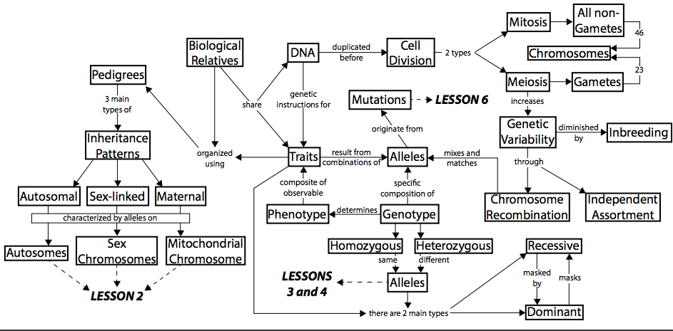

```python
from IPython.display import Image
Image(filename='cm05.jpg')
```

### Concept map

http://content.udacity-data.com/course/bio110/Lesson_5_Concept_Map.pdf

### Genotype and Phenotype

For every characteristic we have 2 forms of a gene - one from our mother, the other from our father.

Genes are part of chromosomes. Differing forms of a gene are called ALLELES, e.g. the alleles for the gene for eye colour are blue, green, brown etc.

PHENOTYPE is the physical appearance resulting from the inherited information. e.g. someone with blue eyes has the phenotype blue eyes.

Genes or alleles can be said to be DOMINANT (shows up in the phenotype) or RECESSIVE (hidden when it is present along with the dominant gene).

Dominant alleles are always expressed in a cell’s phenotype. Only one copy of the dominant allele needs to be present for that characteristic to be expressed.

Dominant alleles are represented by a capital letter, e.g. Brown eyes would be B since brown eyes are dominant to blue eyes.

Recessive alleles are represented by a lower case e.g. blue eyes would be b. They are only expressed when two copies of the allele are present. If only one is present then it becomes ‘masked’ by the dominant allele, e.g. brown eyes is dominant so Bb would show the brown eye characteristic (phenotype).

Blue eyes will only be expressed if the genotype is bb.

Genotype The genotype of an organism demonstrates the alleles present for a particular characteristic.

For example: Genotype Phenotype  
BB Brown eyes Same phenotype as below but different genotype Bb Brown eyes Same phenotype as above but different genotype bb Blue eyes Different phenotype and genotype from both above When two of the same alleles for a gene are present, the genotype is said to be homozygous e.g. BB or bb. But if different alleles are present for the same gene, e.g.. Bb, then they are said to be heterozygous.

### Meiosis

Meiosis is the process by which gametes with a single set of chromosomes are produced. This process takes place in the testes for men and the ovaries for women.

During the process of meiosis a type of body cell called a gamete mother cell divides to form four sex cells Each gamete mother cell contains two sets of chromosomes (23 pairs) and each sex cell contains one set of chromosomes (23) Immediately before gamete production each chromosome in a gamete mother cell uncoils and undergoes DNA replication forming two identical chromatids Shuffling of Chromosomes Each gamete produced from a gamete mother cell receives one chromosome from each pair in the mother cell The separation of the members of a pair of chromosomes is totally at random - therefore there is a huge number of combinations possible. This 'shuffling' of matching pairs of chromosomes is also described as random assortment of chromosomes.

## Problem set 5

http://content.udacity-data.com/course/bio110/Lesson_5_Problem_Set.pdf

## #1

#### Each of the following pedigrees represent one of the major modes of inheritance that welearned about for a dominant trait: (1) Autosomal, (2) Sex-linked, or (3) Maternal. For each pedigree, determine the most likely mode of inheritance.

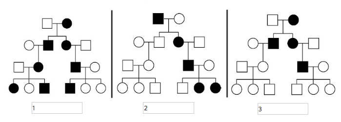

```python
Image(filename='bio0501.jpg')
```

## #2

#### A normal human germ cell before meiosis has how many nuclear chromosomes?

## 46

#### After the first round of cell division?

## 23

#### After the second round of cell division?

## 23

## #3

#### Two first cousins marry, and their first child has the rare autosomal recessive disease galactosemia (inability to process galactose, leading to muscle, nerve, and kidney malfunction). Assuming that the genetic disease is a result of inbreeding, indicate which members of the following pedigree MUST be heterozygous for this to be true. Explain.

1. -/-
2. +/- & +/-
3. +/- and +/-
4. +/- or +/-

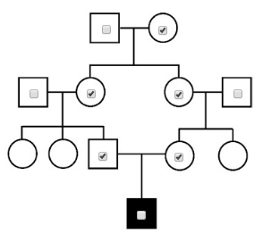

```python
Image(filename='bio0502.jpg')
```

## #4

#### In the same pedigree, assuming that the same first cousins have another child, whatwould be the probability that the new child will be affected by the same genetic disease, galactosemia? Enter your number as a fraction, decimal, or percent.

## 1/4

## #5

#### See the following pedigree for a rare genetic disease trait. Which of the following is the most likely mode of inheritance? Why?

1. Recessive or Dominant
2. Autosomal or Sex-linked or Maternal #### not maternal ( not only 1 maternal line) and not sex-linked (both sexes are equally affected) recessive (skip generations)

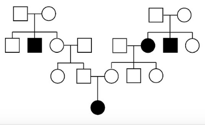

```python
Image(filename='bio0503.jpg')
```

## #6

#### In the same pedigree, if individual A and individual B have a child, what will be theprobability that the child will be affected the same genetic disease? Enter your number as a fraction, decimal, or percent.

## 1/4

## #7

#### Fill in the blank.

### An individual unaffected by a recessive trait cannot be homozygous for the causative allele, whereas an individual affected by a dominant trait must at least be heterozygous for the dominant allele.

#### [Word bank: dominant, recessive, homozygous, heterozygous, affected, unaffected]

## #8

#### A man with KearnsSayre syndrome is affected by many musclerelated deficiencies by the age of 25. At this point the man already has four children. If his syndrome follows a pattern of maternal inheritance, how many of his children would you expect to be affected by KearnsSayre syndrome? Enter a number.

## 0

## #9

#### For a dominant trait like achondroplasia (most common cause of dwarfism), which of thefollowing are true? Select any and all that apply. Why?

#### A. Affected adults must carry a dominant allele

#### B. Affected adults must carry a recessive allele

#### C. Unaffected adults must carry a dominant allele

#### D. Unaffected adults must carry a recessive allele

## A, B, D

#### only -/- will be unaffected for sure

## #10

The accompanying pedigree is for a rare, but relatively mild, hereditary disorder of the skin. Is the disorder inherited as recessive or dominant?

#### no skipping generations

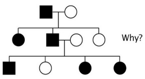

```python
Image(filename='bio0504.jpg')
```

## #11

#### For the same pedigree, using + to represent the dominant allele and  to represent the recessive allele, give the genotype for all of the indicated individuals. You can use a “ / “ (forward slash) to separate alleles if you like.

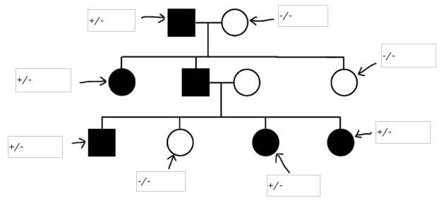

```python
Image(filename='bio0505.jpg')
```

## #12

#### Which of the following best explains the fact that a heterozygous individual affected by an autosomal dominant trait has a onehalf probability of passing the causative allele down to a child? Why?

#### A. Law of segregation

#### B. Chromosome recombination

#### C. Inbreeding

#### D. Mitosis

## A; + one, - another

## #13

#### Duchenne muscular dystrophy is Xlinked and usually affects only males. Victims of the disease become progressively weaker, starting early in life. Assuming you are female, if only your father’s brother had the disease, what is the probability that you have receivedthe allele? Draw a pedigree if you need to for answering this question. Write your answer as a fraction, a decimal, or a percentage

## 0

## #14

#### Again, assuming you are female, if only your mother’s brother (that is, your maternaluncle) had Duchenne muscular dystrophy, what is the probability that you have received the allele from her? Enter your answer as a fraction, a decimal, or a percentage.

## 1/4

## #15

#### True or False. The law of independent assortment describes how every allele pair is divided into two separate gametes during mitosis. (Why?)

## False

### Because of the law of segregation

## #16

#### A man’s maternal grandfather had galactosemia, a rare autosomal recessive disease caused by the inability to process galactose. The man married a woman whose sister had galactosemia. The woman is now pregnant with their first child. In the pedigree, indicate all the individuals that should be shaded to indicate their affected status.

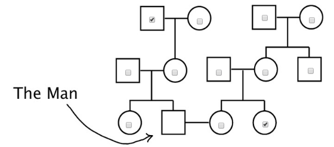

```python
Image(filename='bio0506.jpg')
```

## #17

#### Assuming these are the only affected individuals in the family, what is the probability that this couple’s child will have galactosemia? Enter your answer as a fraction, a decimal, or a percentage

## 1/12

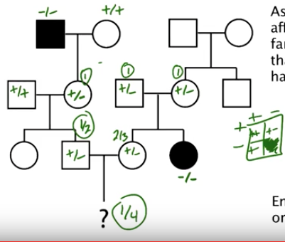

```python
Image(filename='bio0507.jpg')
```

## #18

#### This pedigree concerns a certain rare disease that is incapacitating but not fatal. Determine the most likely mode of inheritance. (Autosomal or Sexlinked or Maternal) (dominant or recessive) Why?

#### recessive (skip generations); sex-linked (only males affected)

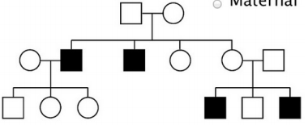

```python
Image(filename='bio0508.jpg')
```

## #19

#### Using “+” for the dominant allele and “” for the recessive allele, enter a possible genotype for the indicated individuals.

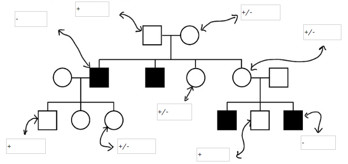

```python
Image(filename='bio0509.jpg')
```

## #20

#### If you were this family’s genetic counselor, indicate what the probability is that each couple might have an affected child. Enter your answer as an integer, fraction, decimal, or percentage.

## 0, 1/4, 0

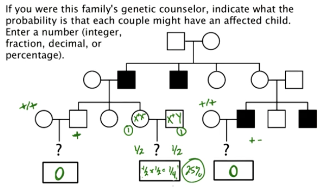

```python
Image(filename='bio0510.jpg')
```

## #21

#### Two genes (A and B) that are responsible for two very different traits can be found on the same chromosome. Based on what you know about recombination during meiosis, which one of the following depictions would most likely result in the maximum number of genotype combinations in gametes from an individual that is heterozygous for both genes? Assuming recombination occurs, what would be the maximum number ofgenotype combinations? Why?

## 4 (A+B+ A+B- A-B+ A-B-)

## #22

#### There are four genes (W, X, Y, and Z) all located very close together on chromosome 3. They are so close together that they are considered linked and virtually no recombination can occur in between them. Assuming no recombination, if an individual is heterozygous for each gene, what is the maximum number of possible genotype combinations in the gametes after meiosis? Why?

## 2; Because there is no recombination

## #23

#### Select the underlined word in the following sentence that is incorrect. Then write the correct word that should replace it.

### Genetic variability achieved by sex, specifically chromosome recombination and independent assortment through meiosis, is undermined by inbreeding which allows forthe possibility of fewer(MORE) homozygous combinations than would be expected in the general population for typically rare recessive alleles.

## Lesson 6

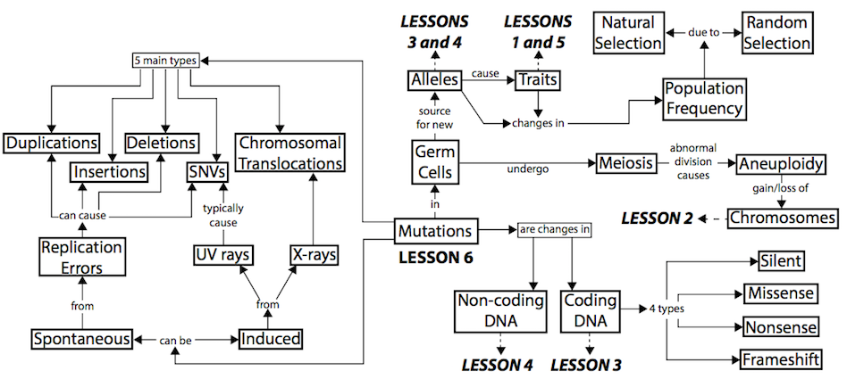

```python
Image(filename='cm06.jpg')
```

### Concept map

http://content.udacity-data.com/course/bio110/Lesson_6_Concept_Map.pdf

```python
webbrowser.open('http://content.udacity-data.com/course/bio110/Lesson_6_Concept_Map.pdf')
```

```
True
```

http://evolution.berkeley.edu/evolibrary/article/evo_01

## *Bottlenecks and founder effects*

### An example of a bottleneck

Northern elephant seals have reduced genetic variation probably because of a population bottleneck humans inflicted on them in the 1890s. Hunting reduced their population size to as few as 20 individuals at the end of the 19th century. Their population has since rebounded to over 30,000 — but their genes still carry the marks of this bottleneck: they have much less genetic variation than a population of southern elephant seals that was not so intensely hunted.

### Founder effects

A founder effect occurs when a new colony is started by a few members of the original population. This small population size means that the colony may have: *- reduced genetic variation from the original population,

- a non-random sample of the genes in the original population.* For example, the Afrikaner population of Dutch settlers in South Africa is descended mainly from a few colonists. Today, the Afrikaner population has an unusually high frequency of the gene that causes Huntington's disease, because those original Dutch colonists just happened to carry that gene with unusually high frequency. This effect is easy to recognize in genetic diseases, but of course, the frequencies of all sorts of genes are affected by founder events.

### Natural Selection

Since more offspring are produced by every species than the environment can support, not all will survive long enough to reproduce.

The following factors may mean that members of the species will not survive:

Predators Disease Competition for light and space Competition for food Competition for a mate Survival of the fittest - those offspring whose phenotypes are better adapted to the environment have a better chance of survival and therefore a greater chance of passing on their genes to the next generation.

The offspring whose phenotypes are less well suited, die before reaching reproductive age, and therefore fail to pass on their genes.

## Problem set 6

http://content.udacity-data.com/course/bio110/geneticcode.pdf

http://content.udacity-data.com/course/bio110/Lesson_6_Problem_Set.pdf

## #1

#### Look at the following sequence from a human gene:

## ...GATCGAGCCGTGAGTCCATGC...

#### You discover that the sequence is altered in one individual to look like this:

## ...GATCGAGCCGTAACGAGTCCATGC...

#### Which of the following best describes the mutation?

### A. Trinucleotide Repeat

### B. Insertion

### C. Duplication

### D. SNV

### E. Deletion

## B

## #2

#### Here is a DNA sequence from a coding region of a gene:

## ATGGGACTAGATACC

#### Determine whether each of the following mutations would be silent, missense, nonsense, or frameshift mutations:

### ATGGGACTAGTTACC (missense)

### ATGGGTCTAGATACC (silent)

### ATGCGACTAGATACC (missense)

### ATGGGACTAAGATACC (frameshift)

## #3

#### A single nucleotide addition and a single nucleotide deletion approximately 15 sites apart in the DNA cause a protein change in sequence from:

## ...Lys – Ser – Pro – Ser – Leu – Asn – Ala – Ala – Lys...

#### to

## ...Lys – Val – His – His – Leu – Met – Ala – Ala – Lys…

#### Based on the changes, enter one possible mRNA nucleotide sequence for the first chain of amino acids. (use the genetic code!)

#### What could be the old mRNA nucleotide sequence? (use the genetic code!)

## #4

#### A single nucleotide addition and a single nucleotide deletion approximately 15 sites apart in the DNA cause a protein change in sequence from:

## ...Lys – Ser – Pro – Ser – Leu – Asn – Ala – Ala – Lys...

#### to

## ...Lys – Val – His – His – Leu – Met – Ala – Ala – Lys…

#### Based on the changes, enter one possible mRNA nucleotide sequence for the new chain of amino acids. (use the genetic code!)

## ## AAA-GUC-CAU-CAC-UUA-AUG-GCA-GCU-AAA

## #5

#### A single nucleotide addition and a single nucleotide deletion approximately 15 sites apart in the DNA cause a protein change in sequence from:

## ...Lys – Ser – Pro – Ser – Leu – Asn – Ala – Ala – Lys...

#### to

## ...Lys – Val – His – His – Leu – Met – Ala – Ala – Lys…

#### To get the new mRNA sequence, which nucleotide has been added and which has been deleted? (use only the RNA letters A, U, G, or C)

## G,A

## #6

#### Which of the following mutations would be expected to be MOST likely to have a harmful effect on an organism? Why?

#### A. A single base change

#### B. A deletion of three bases near the middle of a gene

#### C. A single base deletion near the middle of an intron

#### D. A single base deletion close to the end of the coding sequence

#### E. A single base insertion near the start of the coding sequence

## E .

### It totally changes the coding sequence and producing the protein.

## #7

#### Which of the following repeat errors within a coding sequence would be most likely to be tolerated (cause the least problems) by the individual? Why?

#### A. Dinucleotide repeats (repetition of a 2letter sequence)

#### B. Trinucleotide repeats (repetition of a 3letter sequence)

#### C. Tetranucleotide repeats (repetition of a 4letter sequence)

#### D. Pentanucleotide repeats (repetition of a 5letter sequence)

## B

### A multiple of three, then it does not lead to serious changes.

## #8

#### Which of the following mutations is most likely to result in a protein that lacks normal function? Why?

#### A. Missense mutation

#### B. Frameshift mutation

## B

### The frameshift mutation seriously changes the protein (usually a lot of amino acids).

## #9

#### Fragile X Syndrome, characterized by particular physical features as well as a range of cognitive deficits, is caused by a trinucleotide repeat expansion of the sequence CGG in a gene on the X chromosome. An unaffected individual has around 50 or fewer repeats whereas someone with over 230 is likely to be affected. What is the most likely cause of this sort of repeat expansion? Why?

#### A. Xray radiation

#### B. UV rays

#### C. Replication error

## C

### UV and X rays causes of other types (the base substitutions and the DNA breaking).

## #10

#### Amazingly, the expansion of the CGG sequence from 50 to over 230 repeats on the X chromosome (and causing Fragile X Syndrome) does not occur in the coding region of a gene. The increase in repeats actually occurs near the promoter, causing proteins to accumulate and silence the gene through a process called DNA methylation. If males are affected by one copy but females are not, would you consider this expanded repeat allele to be:

#### A. Dominant

#### B. Recessive

### Why?

## B

### The reason why only men affected - they have only one copy of X chromosome, so they will have a recessive allele in this case.

## #11

#### Trinucleotide repeat expansions (TNREs) are associated with several different human inherited diseases. Certain types of TNREs produce a long stretch of Glutamines (an amino acid abbreviated as Gln) within the encoded protein. This long stretch of glutamines somehow inhibits the function of the protein, thereby causing a disorder.

#### When a TNRE exerts its detrimental effect by producing a glutamine stretch, which of the following statements could be TRUE? Select any and all that apply.

### *A. The TNRE is within the coding sequence of the gene*

#### B. The TNRE affects the promoter preventing transcription

### *C. The trinucleotide sequence could be CAG*

#### D. The trinucleotide sequence could be CCG

## A, C

## #12

#### A position effect is described as a change in phenotype that occurs when the position of a gene is changed from one chromosomal site to a different location. Which of the following would be appropriately described as a position effect? Select any and all that apply.

#### A. A SNV mutation at the position 10 basepairs in front of the promoter region, blocking transcription

#### B. A translocation placing the coding sequence for a musclespecific gene next to an enhancer that is activated in nerve cells

#### C. A nonsense mutation that occurs in the nexttolast exon position of a gene

## B

## #13

#### Which of the following types of mutations change the overall number of chromosomes? Select any and all that apply.

#### A. Frameshift

#### B. Translocation

#### C. Deletion

#### D. Aneuploidy

## D

## #14

#### Select the underlined word in the following sentence that is incorrect. Then write the correct word that should replace it.

#### There are four main types of mutations that occur in coding regions.

##### Silent mutations do not alter the amino acid sequence.

##### Induced (Missense) mutations change one amino acid to another.

##### Nonsense mutations generate a STOP codon from a codon that used to code for another amino acid.

##### And frameshift mutations alter the reading frame such that many amino acids are change.

## #15

#### In the United States, Phenylketonuria, an autosomal recessive metabolic disorder characterized by problems with brain development leading to progressive mental retardation, brain damage, and seizures, affects roughly 1 in every 10,000 newborn babies. Assume a population size of 300,000,000 people for the United States. If the allelic frequency of the Phenylketonuria recessive allele is 0.01, estimate how many individuals in the US would be carriers? Write your answer as a number (integer), and use a calculator if you need it!

```python
(300000000 * (1 - 0.01) * 2) * 0.01
```

```
5940000.0
```

## #16

### True or False.

#### The consequence of errors made (the misincorporation of nucleotides) during transcription is more detrimental to the cell/organism than errors made during DNA replication. Why?

## False

### If the error was made during DNA replication it would affect on every transcription.

## #17

#### An individual acquired a mutation in a skin cell caused by UV light that changes a Lysine (Lys) codon into a Glutamate (Glu) codon. Would this mutation be considered spontaneous or induced? What is the probability that this individual will pass this mutation on to their offspring? Write your answer as a fraction, percentage, or decimal.

## Induced. 0

## #18

#### Although the phrase “gene pool” is sometimes used loosely to refer to genes in a group of individuals, technically it is defined as the collective genetic information contained within a population of sexually reproducing organisms. A large gene pool indicates immense genetic diversity of various alleles within a population that can withstand rounds of intense selection. With this in mind, which of the following have the net effect of reducing the gene pool? Select any and all that apply.

#### A. Meiosis

#### B. Extensive inbreeding

#### C. Population bottlenecks

#### D. Natural or random selection

#### E. Random mating

## B, C, D

## #19

#### Consider the populations that have the genotype frequencies shown in the followingtable:

#### Population Genotype +/+ Genotype +/- Genotype -/-

#### 1 1.0 0.0 0.0

#### 2 0.0 1.0 0.0

#### 3 0.0 0.0 1.0

#### 4 0.25 0.5 0.25

#### What are the allelic frequencies in each population? Enter a number/decimal for each.

## '+' 1 - 1.0, 2 - 0.5, 3 - 0.0, 4 - 0.5

## '-' 1 - 0.0, 2 - 0.5, 3 - 1.0, 4 - 0.5

## #20

#### Phenotypic, genotypic, and allelic frequencies can all be assessed for a population if enough information is known. Frequencies are measured from 0 to 1, with 0 being a complete absence in the population and 1 comprising the entirety of the population. For the autosomal recessive trait of lactose intolerance, heterozygous individuals are unaffected because one copy of the dominant allele is enough to be lactase persistent.

#### Out of a population of 10,000 where 2,000 are lactase persistent (dominant) and 8,000 are lactase non-persistent (recessive and lactose intolerant), there are 1,500 heterozygous individuals. Fill in the table for the phenotypic, genotypic, and allelic frequencies for the trait of lactase persistence.

Allelic

### Phenotypic frequency ___ Lactase Persis: 0.2 Non-persis: 0.8

### Genotypic frequency ___ +/+: 0.05 +/-: 0.15 -/- 0.8

### Allelic frequency ___ + : 0.125 - : 0.875

## #21

#### Not only can selection pressures (natural or random) alter allelic frequencies, but so can genetic drift. Genetic drift is simply the change in allelic frequencies in a population due to random sampling effects over the formation of successive generations. The expected population dynamics indicates that neutral alleles are predicted to eventually become fixed at zero or 100% frequency in the absence of other mechanisms affecting allele distributions. Which of the following examples show an instance where the dominant (+) allele is fixed at 0 or 100%? Select any and all that apply. Why?

#### A. 100% individuals with the dominant phenotype, 25% have two dominant alleles

#### B. 100% individuals with the dominant phenotype, 0% have one recessive allele

#### C. 100% individuals with the recessive phenotype, 100% have two recessive alleles

#### D. 50% individuals with the recessive phenotype, 0% have two dominant alleles

## B, C

## #22

#### Fill in the blanks using words from the word bank.

#### Spontaneous mutations like those from replication errors can cause duplications, insertions, deletions , and individual SNVs. Induced mutations from X-rays can cause chromosomal translocations . No matter the source, mutations in germ cells get passed down to the next generation and have the potential to spread in a population in response to selection .

#### (Word bank: germ cells, induced, deletions, selection, population, spontaneous, replication errors, translocations)

## #23

#### Achondroplasia is one of the most common forms of dwarfism caused by an autosomal dominant mutation in the coding region of a single gene. Out of 1,500,000 live births, the number of babies born with achondroplasia was 31. Among those 31 babies, 18 of them had one parent with achondroplasia. The remaining babies had two unaffected parents. For this group of 1,500,000 babies, which of the following is most likely the mutation rate? Which of the following is most likely the mutation frequency? Why?

#### Rate 31/1500000 31/3000000 18/1500000 18/3000000 13/1500000 13/3000000

#### Frequency 31/1500000 31/3000000 18/1500000 18/3000000 13/1500000 13/3000000

```python
# Rate:
print (31-18), '/', (2*1500000)
```

```
13 / 3000000
```

```python
# Frequency:
print 31, '/', (2*1500000)
```

```
31 / 3000000
```